# IODS course project

Ville Kuorikoski

# Introduction to Open Data Science - Course Project

# Week 1 - About the project

*I’m feeling exited to get started with the course assignments. I hope to learn new techniques to visualize and analyze the data I produce.*

*The Exercise Set was a good introduction to R. I didn’t feel like both the textbook and the exercise file were super necessary because, most of the time, for me it was enough to read the textbook. I mostly did not deepen my understanding on the subject by running the code myself since the code output was already written on the textbook.*

*My favorite topics were the ones that were the most difficult also. I liked trying to understand the flow of the code in the data summarising chapter where the different functions worked together.*

**Here is a link to my project GitHub page:** https://github.com/vilkuo/IODS-project

```r
# This is a so-called "R chunk" where you can write R code.

date()
```

```
## [1] "Mon Nov 21 16:40:37 2022"
```

# Week 2 - Regression and model validation

*This week I started building habits while working with RStudio and GitHub. Working with R in RStudio starts to feel comfortable.*

*I learned different methods and ways to manipulate data in tables using R. I also managed to slip in ways to make my code shorter and clearer which I have learned while programming with other languages. This week’s exercises also taught me how to create different kind of plots and how to customize them to my liking.*

### Read in data from file

Here the data is read from a previously created csv file to a data frame object ‘lrn14’. The contents of the data is explained below.

```r
# Access different necessary libraries
library(plyr)
library(tidyverse)
library(GGally)
```

```r
library(ggplot2)
library(patchwork)

# Read and store data from local file to 'lrn14' variable
lrn14 <- read.csv("data/learning2014.csv")

# Explore the data by printing the dimensions of it into console
dim(lrn14)
```

```
## [1] 166   7
```

Output fromt he dim() function shows that the data frane has 166 entries in 7 different columns.

```r
# Show the first 6 rows of the of the data in table format
head(lrn14)
```

```
##   gender age attitude     deep  stra     surf points
## 1      F  53      3.7 3.583333 3.375 2.583333     25
## 2      M  55      3.1 2.916667 2.750 3.166667     12
## 3      F  49      2.5 3.500000 3.625 2.250000     24
## 4      M  53      3.5 3.500000 3.125 2.250000     10
## 5      M  49      3.7 3.666667 3.625 2.833333     22
## 6      F  38      3.8 4.750000 3.625 2.416667     21
```

In the table you can see the first 6 rows of the data. The rows represents the the data collected from different students

The data consist of 7 different columns:

1. gender: Gender of the student (M for male and F for female)
2. age: Age of the student
3. attitude: Student’s attitude towards statistics in Likert scale (1-5)
4. deep: Average score of student’s tendency towards deep learning in Likert scale
5. stra: Average score of student’s tendency towards strategic learning in Likert scale
6. surf: Average score of student’s tendency towards surface learning in Likert scale
7. points: Total points from exam

### Exploring the data

To get an quick overview of each of the variables, summary() function is used to print different key values for them.

```r
# Print the overall summary of the different variables in 'lrn14'
summary(lrn14)
```

```
##     gender               age           attitude          deep
##  Length:166         Min.   :17.00   Min.   :1.400   Min.   :1.583
##  Class :character   1st Qu.:21.00   1st Qu.:2.600   1st Qu.:3.333
##  Mode  :character   Median :22.00   Median :3.200   Median :3.667
##                     Mean   :25.51   Mean   :3.143   Mean   :3.680
##                     3rd Qu.:27.00   3rd Qu.:3.700   3rd Qu.:4.083
##                     Max.   :55.00   Max.   :5.000   Max.   :4.917
##       stra            surf           points
##  Min.   :1.250   Min.   :1.583   Min.   : 7.00
##  1st Qu.:2.625   1st Qu.:2.417   1st Qu.:19.00
##  Median :3.188   Median :2.833   Median :23.00
##  Mean   :3.121   Mean   :2.787   Mean   :22.72
##  3rd Qu.:3.625   3rd Qu.:3.167   3rd Qu.:27.75
##  Max.   :5.000   Max.   :4.333   Max.   :33.00
```

In the summary() output you can see the structure of the data for each variable.

A couple of thoughts from the summaries:

- The **age** range is wide but the ages of the students are concentrated within 20 to 30 year olds as can be seen from the 1st and 3rd quartiles being well within the range of 20-30.
- There seems to be wide distribution of **attitude** among the student. The mean and median values are close to the middle of the Likert scale so the distribution is even.
- The average values of the **deep**, **stra** and **surf** are very different from each other which gives an expression of tendency towards certain type of learning among the students.

#### Graphical overview of the data

Density plots give good understanding about the distribution of each variable. The densities can be further separated by gender. Mean value can also be plotted for both genders into the plots.

```r
# Create separate data frames holding mean values for each variable separated by gender
cdeep <- ddply(lrn14, "gender", summarise, deep.mean=mean(deep))
cstra <- ddply(lrn14, "gender", summarise, stra.mean=mean(stra))
csurf <- ddply(lrn14, "gender", summarise, surf.mean=mean(surf))
cpoints <- ddply(lrn14, "gender", summarise, points.mean=mean(points))
cattitude <- ddply(lrn14, "gender", summarise, attitude.mean=mean(attitude))

# Print the mean values for each variable separated by gender
cattitude
```

```
##   gender attitude.mean
## 1      F      2.990000
## 2      M      3.442857
```

```r
cdeep
```

```
##   gender deep.mean
## 1      F  3.656818
## 2      M  3.724702
```

```r
cstra
```

```
##   gender stra.mean
## 1      F  3.201136
## 2      M  2.964286
```

```r
csurf
```

```
##   gender surf.mean
## 1      F  2.829545
## 2      M  2.703869
```

```r
cpoints
```

```
##   gender points.mean
## 1      F    22.32727
## 2      M    23.48214
```

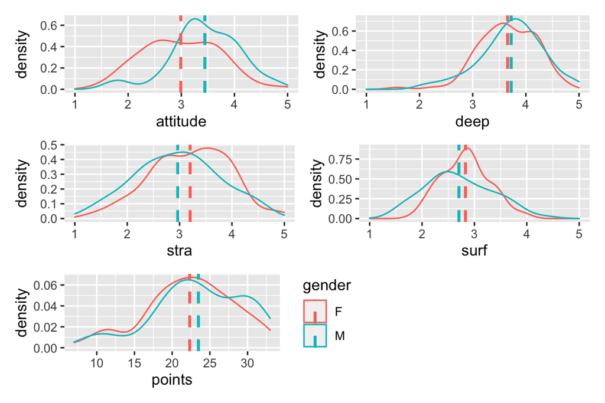

```r
# Create and save ggplot() objects into variables for printing the plots together
attitude_distr <- lrn14 %>%
  ggplot(aes(x = attitude, colour=gender)) +
  geom_density() +
  geom_vline(data=cattitude, aes(xintercept=attitude.mean, colour=gender),
             linetype="dashed", size=1) +
  expand_limits(x = c(1, 5)) +
  theme(legend.position = "none")

deep_distr <- lrn14 %>%
  ggplot(aes(x = deep, colour=gender)) +
  geom_density() +
  geom_vline(data=cdeep, aes(xintercept=deep.mean, colour=gender),
             linetype="dashed", size=1) +
  expand_limits(x = c(1, 5)) +
  theme(legend.position = "none")

stra_distr <- lrn14 %>%
  ggplot(aes(x = stra, colour=gender)) +
  geom_density() +
  geom_vline(data=cstra, aes(xintercept=stra.mean, colour=gender),
             linetype="dashed", size=1) +
  expand_limits(x = c(1, 5)) +
  theme(legend.position = "none")

surf_distr <- lrn14 %>%
  ggplot(aes(x = surf, colour=gender)) +
  geom_density() +
  geom_vline(data=csurf, aes(xintercept=surf.mean, colour=gender),
             linetype="dashed", size=1) +
  expand_limits(x = c(1, 5)) +
  theme(legend.position = "none")

points_distr <- lrn14 %>%
  ggplot(aes(x = points, colour=gender)) +
  geom_density() +
  geom_vline(data=cpoints, aes(xintercept=points.mean, colour=gender),
             linetype="dashed", size=1)

# Print all the plots together
(attitude_distr + deep_distr) / (stra_distr + surf_distr) / (points_distr + plot_spacer())
```

Comparing the mean values, males both have better attitude towards statistics and higher exam points. Males seem to prefer deep learning more the females ever so slightly. Females prefer strategic and surface learning more than males.

Distribution of the points and deep learning preferences are towards the upper values. The distribution of strategic learning preferences seem to be close to normal distribution.

#### Scatter matrix

Scatter matrix makes is easy to interpret the data in one plot. You can easily also see the correlation between different variables in the data frame.

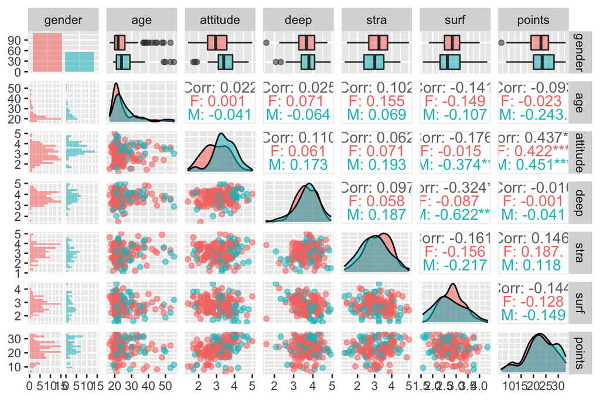

```r
# Define groups from gender for plotting
group <- NA
group[lrn14$gender == "M"] <- 1
group[lrn14$gender == "F"] <- 2

# Print scatter matrix for 'lrn14' with aesthetic elements
p <- ggpairs(lrn14, mapping = aes(col = gender, alpha = 0.3), lower = list(combo = wrap("facethist", bins = 20)))
p
```

From the plot you can see that **attitude** has highest overall correlation with points. Second is **stra** and third is **surf**.

### Fitting a linear regression model and analysing the results

Three variables will be selected based on the highest correlation with points and chosen as explanatory variables in a regression model targeting points variable.

```r
# Create model object 'm'
m1 <- lm(points ~ attitude + stra + surf, data = lrn14)

# Print a summary of the model
summary(m1)
```

```
##
## Call:
## lm(formula = points ~ attitude + stra + surf, data = lrn14)
##
## Residuals:
##      Min       1Q   Median       3Q      Max
## -17.1550  -3.4346   0.5156   3.6401  10.8952
##
## Coefficients:
##             Estimate Std. Error t value Pr(>|t|)
## (Intercept)  11.0171     3.6837   2.991  0.00322 **
## attitude      3.3952     0.5741   5.913 1.93e-08 ***
## stra          0.8531     0.5416   1.575  0.11716
## surf         -0.5861     0.8014  -0.731  0.46563
## ---
## Signif. codes:  0 '***' 0.001 '**' 0.01 '*' 0.05 '.' 0.1 ' ' 1
##
## Residual standard error: 5.296 on 162 degrees of freedom
## Multiple R-squared:  0.2074, Adjusted R-squared:  0.1927
## F-statistic: 14.13 on 3 and 162 DF,  p-value: 3.156e-08
```

In the coefficients table, the estimate values for each variable describe the increase in points when the variable in question increases by one. Estimates are followed by the standard errors of each coefficients and t-values and finally the p-values.

From the summary you can see on the F-statistic on the bottom that p-value is very low meaning that at least one explanatory variable is significantly related to the points variable. Looking at the coefficients table, you can see from the last column of p-values that attitude has very low p-value meaning statistically significant relationship to the points variable. The stra and surf coefficients aren’t significant shown by the lack of stars at the end of the table.

```r
# Print the measure of error rate of the model
sigma(m1)/mean(lrn14$points)
```

```
## [1] 0.2331477
```

From this value you can see that the error rate is 23% which can be considered to be high.

#### Improving the model

Removing statistically insignificant coefficients from the model will help improving the model

```r
# Create model object 'm' with only the attitude variable
m2 <- lm(points ~ attitude, data = lrn14)

# Print a summary of the model
summary(m2)
```

```
##
## Call:
## lm(formula = points ~ attitude, data = lrn14)
##
## Residuals:
##      Min       1Q   Median       3Q      Max
## -16.9763  -3.2119   0.4339   4.1534  10.6645
##
## Coefficients:
##             Estimate Std. Error t value Pr(>|t|)
## (Intercept)  11.6372     1.8303   6.358 1.95e-09 ***
## attitude      3.5255     0.5674   6.214 4.12e-09 ***
## ---
## Signif. codes:  0 '***' 0.001 '**' 0.01 '*' 0.05 '.' 0.1 ' ' 1
##
## Residual standard error: 5.32 on 164 degrees of freedom
## Multiple R-squared:  0.1906, Adjusted R-squared:  0.1856
## F-statistic: 38.61 on 1 and 164 DF,  p-value: 4.119e-09
```

From the coefficients table, you can see that increasing attitude with 1 point predicts increase of 3.5 in exam points.

The adjusted multiple R-squared value being closer to 0 than 1 indicate the the model explains only a small portion of the variance in points variable. Variability in exam succession measured in points have to do mostly with something else than attitude.

#### Regression model diagnostic plots

Producing the diagnostic plots Residuals vs Fitted values, Normal QQ-plot and Residuals vs Leverage for the model ‘m2’.

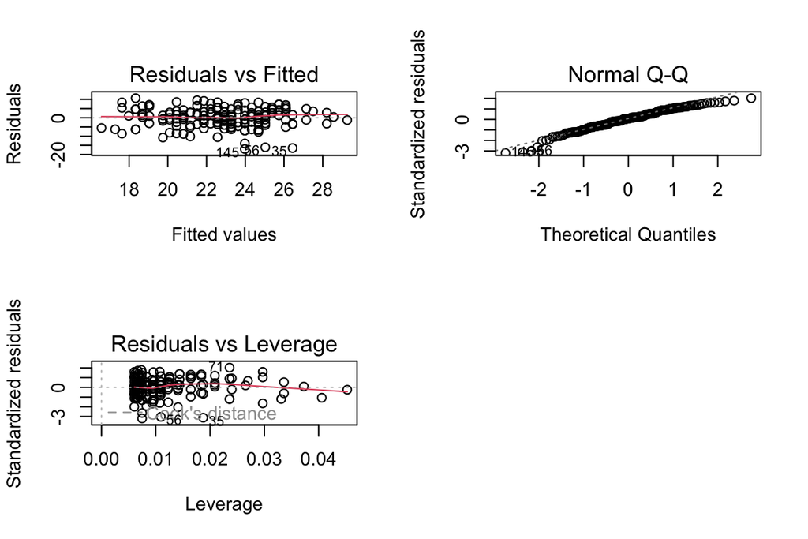

```r
# Combine the diagnostic plots in one figure
par(mfrow = c(2,2))
plot(m2, which = c(1,2,5))
```

In the Residuals vs Fitted plot, the residuals are scattered decently equally around the horizontal line indicating a linear relationship between the variables.

Based on the Normal Q-Q plot the model seems to be normally distributed due to the points aligning well into a line. The exceptions aren’t that far of the line either.

The Residuals vs Leverage plot doesn’t highlight any influential outliers in the data since there arent any points ant the top or bottom right corners in the plot.

# Week 3 - Logistic regression

*I learned a lot more about regression models due to learning my lesson from the last week’s assignment and the feedback I got for my assignment. Working with linear regression models also helped a lot when learning about the logistic regression.*

*Working with GitHub and RStudio seems to be fluent already so I feel like I can pay more attention to learning about the statistics itself. Also I feel like my programming background helps a lot with that also.*

## Analysis

```r
# Load the necessary libraries
library(tidyr); library(dplyr); library(forcats); library(GGally); library(ggplot2); library(patchwork)
```

### Read in the data

Read the data into a variable and explore the contents

```r
# Read the data from a local file and store it in 'alc'
alc <- read.table("data/alc.csv",sep=",", header=TRUE)

# Print a overview of the data
glimpse(alc)
```

```
## Rows: 370
## Columns: 35
## $ school     <chr> "GP", "GP", "GP", "GP", "GP", "GP", "GP", "GP", "GP", "GP",…
## $ sex        <chr> "F", "F", "F", "F", "F", "M", "M", "F", "M", "M", "F", "F",…
## $ age        <int> 18, 17, 15, 15, 16, 16, 16, 17, 15, 15, 15, 15, 15, 15, 15,…
## $ address    <chr> "U", "U", "U", "U", "U", "U", "U", "U", "U", "U", "U", "U",…
## $ famsize    <chr> "GT3", "GT3", "LE3", "GT3", "GT3", "LE3", "LE3", "GT3", "LE…
## $ Pstatus    <chr> "A", "T", "T", "T", "T", "T", "T", "A", "A", "T", "T", "T",…
## $ Medu       <int> 4, 1, 1, 4, 3, 4, 2, 4, 3, 3, 4, 2, 4, 4, 2, 4, 4, 3, 3, 4,…
## $ Fedu       <int> 4, 1, 1, 2, 3, 3, 2, 4, 2, 4, 4, 1, 4, 3, 2, 4, 4, 3, 2, 3,…
## $ Mjob       <chr> "at_home", "at_home", "at_home", "health", "other", "servic…
## $ Fjob       <chr> "teacher", "other", "other", "services", "other", "other", …
## $ reason     <chr> "course", "course", "other", "home", "home", "reputation", …
## $ guardian   <chr> "mother", "father", "mother", "mother", "father", "mother",…
## $ traveltime <int> 2, 1, 1, 1, 1, 1, 1, 2, 1, 1, 1, 3, 1, 2, 1, 1, 1, 3, 1, 1,…
```

[output cut: 22 more lines]

In the output above, there are 35 columns representing 370 different student’s grades, social, school and demographic features. The data set describes the average values in two different subjects, Math and Portuguese, for student absences, class failures and the grades from the first and second periods and the final grade (G1, G2 and G3 respectively). ‘Paid’ column represents if the student has had extra paid classes in Math as an binary, yes or no value. Other columns are not related to the courses but present background information about the student instead. ‘Alc_use’ means the average alcohol consumption between weekdays and weekends on a Likert scale where 5 means very high consumption. ‘High_use’ column shows ‘TRUE’ if ‘alc_use’ is higher than 2 and ‘FALSE’ otherwise.

Other columns with either nominal or binary values are ‘school’(student’s school), ‘sex’, ‘address’(urban or rural), ‘famsize’(less or equal to 3 or greater than 3), ‘Pstatus’(parents living together or apart), ‘Mjob’(mother’s job field), ‘Fjob’ (father’s job field), ‘reason’(reason to choose this school), ‘guardian’, ‘schoolsup’(extra educational support from school), ‘famsup’(extra educational support from family), ‘activities’(extra-curricular activities), ‘nursery’(attended nursery school), ‘higher’(wants to take higher education), ‘internet’(access to internet at home), ‘romantic’(in a romantic relationship).

Rest of the columns have numeric value on a scale from 1 to either 4 or 5.

### Relationship between alcohol consumption and other features

I’m interested to see if there is connection between alcohol consumption and the student’s absences (‘absences’) because I think alcohol consumption will be higher with students that have more school absences. I also think higher alcohol consumption could be more prevalent in students with lower final grade of the courses (‘G3’). Other values I’m interested in while exploring the relationship to alcohol consumption are the quality of family relationships (‘famrel’) and the amount of times going out with friends (‘goout’). I expect the alchol consumption to be higher with students that have lower family relationships and go out more with friends.

#### Exploring the distributions and relationships in the data

##### Distributions of the data

```r
# Print the summary of the 4 previously selected variables in the data set
summary(select(alc, high_use, absences, G3, famrel, goout))
```

```
##   high_use          absences            G3            famrel
##  Mode :logical   Min.   : 0.000   Min.   : 0.00   Min.   :1.000
##  FALSE:259       1st Qu.: 1.000   1st Qu.:10.00   1st Qu.:4.000
##  TRUE :111       Median : 3.000   Median :12.00   Median :4.000
##                  Mean   : 4.511   Mean   :11.52   Mean   :3.935
##                  3rd Qu.: 6.000   3rd Qu.:14.00   3rd Qu.:5.000
##                  Max.   :45.000   Max.   :18.00   Max.   :5.000
##      goout
##  Min.   :1.000
##  1st Qu.:2.000
##  Median :3.000
##  Mean   :3.116
##  3rd Qu.:4.000
##  Max.   :5.000
```

From the numerical summary can be seen that almost a third of the students are categorized with high consumption of alcohol. Number of school absences vary from 0 to 45 but the values are concentrated around the mean value of 4.511 because the 1st and 3rd quartiles are close to the mean. Final grade score vary from 0 to 18 while 20 is the maximum possible grade. The mean final grade is around the middle of the possible points. Family relationships are very good (4) on average and large portion (>75%) of the values are at least 4. The amount of times going out with friends seem to be more evenly distributed than family relationships based on the quantiles being evenly distributed.

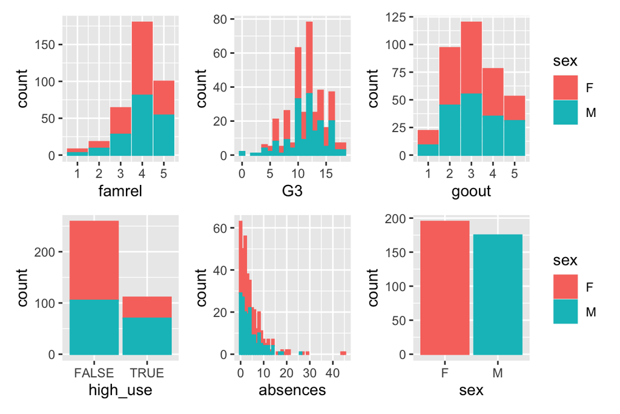

```r
# Save the plots as variables
p1 <- alc %>% ggplot(aes(famrel, col=sex, fill=sex)) + geom_bar() +
  theme(legend.position = "none")
p2 <- alc %>% ggplot(aes(G3, col=sex, fill=sex)) + geom_bar() +
  theme(legend.position = "none")
p3 <- alc %>% ggplot(aes(goout, col=sex, fill=sex)) + geom_bar()
p4 <- alc %>% ggplot(aes(high_use, col=sex, fill=sex)) + geom_bar() +
  theme(legend.position = "none")
p5 <- alc %>% ggplot(aes(absences, col=sex, fill=sex)) + geom_bar() +
  theme(legend.position = "none")
p6 <- alc %>% ggplot(aes(sex, col=sex, fill=sex)) + geom_bar()

# Print the plots in a grid
(p1 + p2 + p3) / (p4 + p5 + p6)
```

Based on the graphical distributions highlighting the values between genders, not big differences can be seen in them except in alcohol use. Males seem to have more members flagged with high use than females even though there are more females in the data than males. Other variables seem to be evenly distributed when comparing the distributions between each gender.

##### Relationships of different variables to alcohol consumption

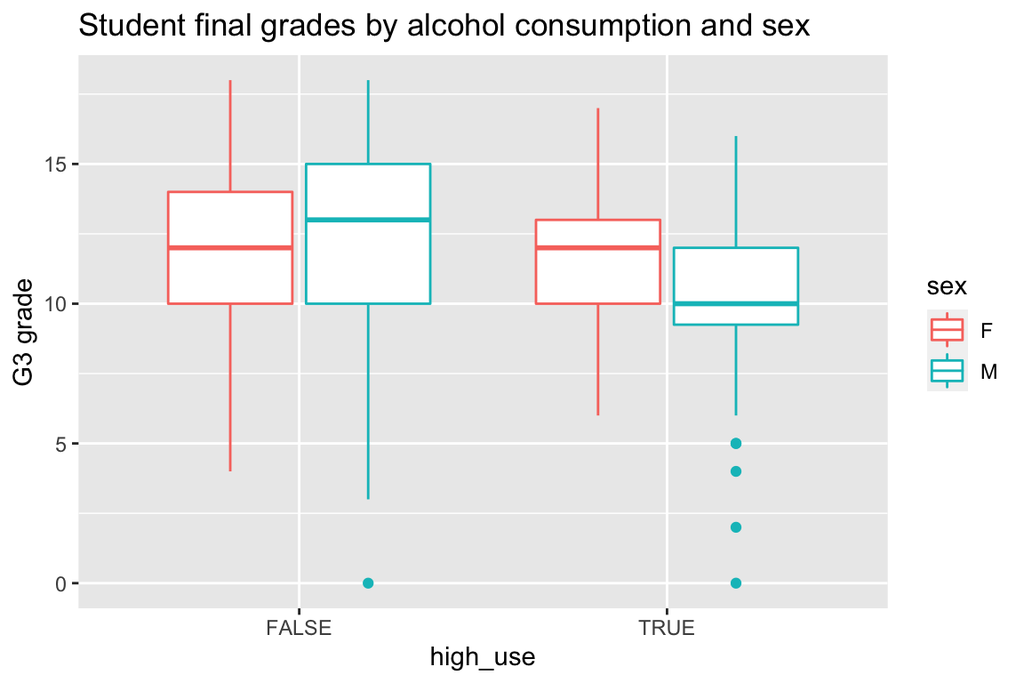

```r
# Initializes box plots for the 4 numeric variables compared to alcohol consumption
g1 <- ggplot(alc, aes(x = high_use, y = G3, col = sex)) +
  geom_boxplot() +
  ylab("G3 grade") +
  ggtitle("Student final grades by alcohol consumption and sex")

g2 <- ggplot(alc, aes(x = high_use, y = famrel, col = sex)) +
  geom_boxplot() +
  ylab("Family relation quality") +
  ggtitle("Student family relationship quality by alcohol consumption and sex")

g3 <- ggplot(alc, aes(x = high_use, y = goout, col = sex)) +
  geom_boxplot() +
  ylab("Going out") +
  ggtitle("Student's amount of going out with friends by alcohol consumption and sex")

g4 <- ggplot(alc, aes(x = high_use, y = absences, col = sex)) +
  geom_boxplot() +
  ylab("Absences") +
  ggtitle("Student absences by alcohol consumption and sex")

g1
```

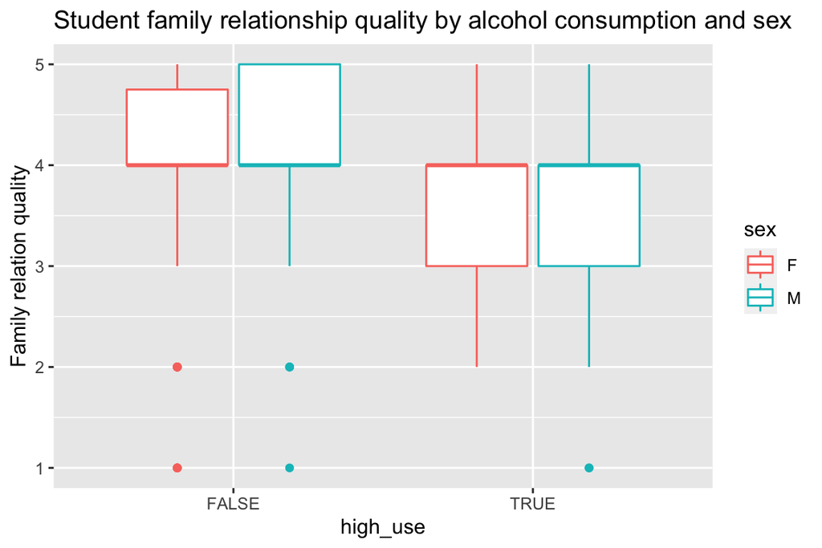

```r
g2
```

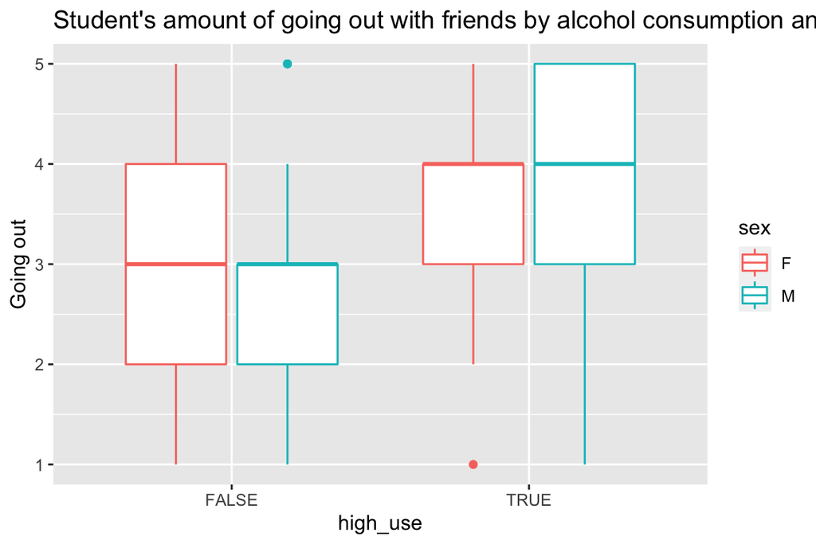

```r
g3
```

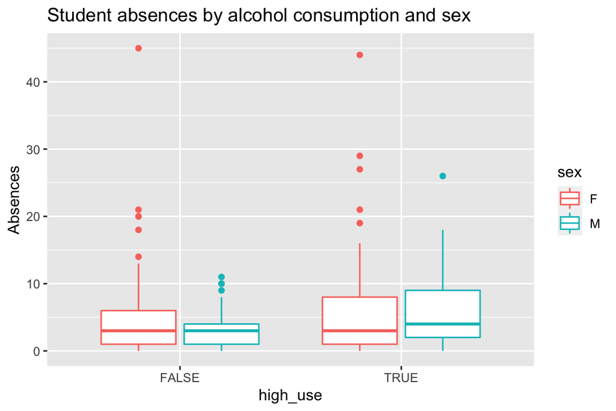

```r
g4
```

### Fitting a logistic regression model to the data

#### Fit the model and explore the model summary

```r
# Fit a logistic regression model with glm() and save it as 'm'
m <- glm(high_use ~ absences + G3 + famrel + goout, data = alc, family = "binomial")

# Print the summary of the model
summary(m)
```

```
##
## Call:
## glm(formula = high_use ~ absences + G3 + famrel + goout, family = "binomial",
##     data = alc)
##
## Deviance Residuals:
##     Min       1Q   Median       3Q      Max
## -1.9326  -0.7803  -0.5320   0.9092   2.4031
##
## Coefficients:
##             Estimate Std. Error z value Pr(>|z|)
## (Intercept) -1.73174    0.80178  -2.160  0.03078 *
## absences     0.07162    0.02188   3.273  0.00106 **
## G3          -0.04464    0.03945  -1.132  0.25780
## famrel      -0.36863    0.13674  -2.696  0.00702 **
## goout        0.75179    0.12147   6.189 6.05e-10 ***
## ---
## Signif. codes:  0 '***' 0.001 '**' 0.01 '*' 0.05 '.' 0.1 ' ' 1
##
## (Dispersion parameter for binomial family taken to be 1)
##
##     Null deviance: 452.04  on 369  degrees of freedom
## Residual deviance: 381.52  on 365  degrees of freedom
## AIC: 391.52
##
## Number of Fisher Scoring iterations: 4
```

#### Coefficients as odds ratios

```r
# Compute odds ratios (OR)
OR <- coef(m) %>% exp

# Compute confidence intervals (CI)
CI <- confint(m) %>% exp

# Print odds ratios and confidence intervals
cbind(OR, CI)
```

```
##                    OR      2.5 %    97.5 %
## (Intercept) 0.1769767 0.03541675 0.8287672
## absences    1.0742511 1.03026197 1.1240662
## G3          0.9563393 0.88504531 1.0335076
## famrel      0.6916828 0.52742137 0.9032721
## goout       2.1207877 1.68202321 2.7109929
```

From the odds ratios above it can be estimated that increasing the categorical amount of going out with friends (‘goout’) by 1 **increases** the likelihood to be a high user of alcohol by ~112%. Increasing the amount of being absent (‘absences’) from school by 1 **increases** the likelihood to be a high user of alcohol by ~7%. Increasing the categorical value of the quality of family relationship (‘famrel’) by 1 **decreases** the likelihood to be a high user of alcohol by ~31%. For final grades (‘G3’), the results are **not statistically significant** because the 95% confidence interval includes the value 1.0.

I did not hypothesize the explanatory power of these variables but the existence of correlation itself instead. In addition to the graphical analysis that I did before, these results further support my hypothesis of absences, family relations and going out with friends being related to alcohol consumption. The final grades not explaining alcohol consumption contradicts my hypothesis.

### Prediction based on the model

#### Produce a comparison between predicted values and actual values

For the new model, ‘G3’ will be left out because it did not have statistical relationship with alcohol consumption.

```r
# Fit a new model to the data without G3 this time
m1 <- glm(high_use ~ absences + famrel + goout, data = alc, family = "binomial")

# Use predict() to predict the probability of high_use
probabilities <- predict(m1, type = "response")

# Add the predicted probabilities to 'alc'
alc <- mutate(alc, probability = probabilities)

# Make prediction of high_use based on probability
alc <- mutate(alc, prediction = probability > 0.5)

# Tabulate the high_use against the predictions
table(high_use = alc$high_use, prediction = alc$prediction)
```

```
##         prediction
## high_use FALSE TRUE
##    FALSE   236   23
##    TRUE     67   44
```

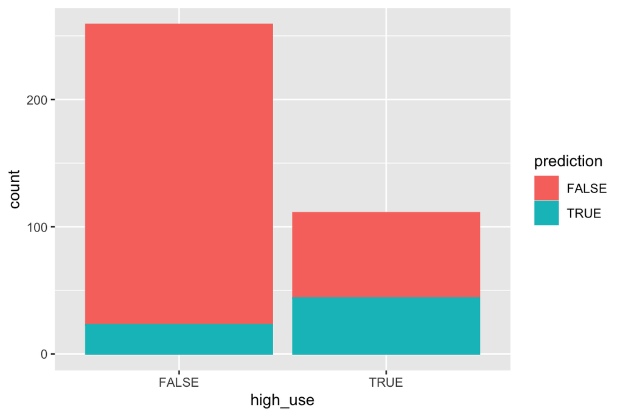

```r
# Plot the high_use against the predictions
alc %>% ggplot(aes(high_use, col=prediction, fill=prediction)) + geom_bar()
```

The bar plot especially highlights the performance of the prediction power of the model. Vast majority of the actual false values were predicted by the model indicated by the proportion of the red colour in the left bar. True values instead were not as accurately predicted as the false values since slightly over half of the actual true values were predicted to be false by the model.

#### Calculate the proportion of incorrectly predicted values

```r
# The proportion of false predictions of the total predictions for model 'm1'
# where 'abs(alc$high_use - alc$prediction)' returns 1 when prediction is
# wrong because alcohol usage equals 1 when True and 0 when False.
# Therefore true positives and false negatives cancel each other out.
# sum() sums the amount of wrong predictions in the table
# nrow() returns the total amount of observations which equals to the amount of predictions
sum(abs(alc$high_use - alc$prediction)) / nrow(alc)
```

```
## [1] 0.2432432
```

```r
# Print the same proportion of false predictions for randomly guessed values by sample() function
# Set seed of 1 is used for the random number generator to always get the same value for this assignment
set.seed(1)
sum(abs(alc$high_use - sample(c(0,1), replace=TRUE, size=nrow(alc)))) / nrow(alc)
```

```
## [1] 0.4864865
```

The value for the proportion of false predictions is not that high considering the lack of refinement for the model in this assignment. Comparing the value derived from ‘m1’ model to the value from using sample() function shows that the model predicts the outcome significantly better than random guessing.

(more chapters to be added similarly as we proceed with the course!)